# Sedimentation Baseline Robustness Analysis

Ross Cunning

2026-10-01

```r
library(tidyverse)
library(readxl)
library(janitor)
library(patchwork)

project_dir <- if (basename(getwd()) == "code") dirname(getwd()) else getwd()
knitr::opts_knit$set(root.dir = project_dir)
knitr::opts_chunk$set(
  echo = TRUE,
  message = FALSE,
  warning = FALSE,
  fig.align = "center"
)

theme_set(
  theme_minimal(base_size = 10) +
    theme(
      panel.grid.minor = element_blank(),
      plot.title.position = "plot"
    )
)
```

# 1 Purpose and interpretation

The official pre-construction survey appears higher than much of the subsequent monitoring record at many transects. This report tests whether that pattern is large, spatially consistent, and unusual relative to ordinary survey-to-survey variation. It then compares alternative meter-specific reference formulations.

These analyses diagnose **representativeness**, not intent or data quality. A high official baseline could reflect a real but transient sediment state, seasonality, measurement differences, or natural redistribution. None of the tests alone establishes the cause. Likewise, construction-period observations are not automatically impact-free; alternatives using Con1 or Con2 must be interpreted as sensitivity references rather than replacements for the regulatory baseline unless their use is independently justified.

# 2 Data preparation

```r
sediment_dir <- "data/sedimentation_monitoring"

construction_files <- list.files(
  file.path(sediment_dir, "2_During-Construction", "Data"),
  pattern = "\\.xlsx$",
  recursive = TRUE,
  full.names = TRUE
)

construction_file_index <- tibble(source_file = construction_files) %>%
  mutate(
    source_file_name = basename(source_file),
    construction_survey_n = map_int(
      str_extract_all(source_file_name, "(?i)(?<=con)\\d+"),
      ~ if (length(.x) == 0) NA_integer_ else max(as.integer(.x))
    )
  ) %>%
  filter(!is.na(construction_survey_n)) %>%
  arrange(desc(construction_survey_n), desc(file.info(source_file)$mtime))

latest_construction_file <- construction_file_index %>%
  slice(1) %>%
  pull(source_file)

sediment_raw <- read_excel(
  latest_construction_file,
  sheet = "SedimentDepth_RawData"
) %>%
  clean_names() %>%
  mutate(
    date = as.Date(date),
    survey = str_squish(survey),
    survey_n = if_else(
      survey == "Baseline",
      0L,
      as.integer(str_extract(survey, "\\d+"))
    ),
    transect = str_replace_all(str_squish(transect), "\\s+", "_"),
    meter = as.integer(meter),
    meter_mean_sediment_cm = rowMeans(
      pick(starts_with("sed_depth_cm_")),
      na.rm = TRUE
    )
  )

transect_survey_coverage <- sediment_raw %>%
  summarize(
    n_meter_positions = n_distinct(meter),
    n_surveys = n_distinct(survey),
    latest_survey_n = max(survey_n),
    has_baseline = any(survey_n == 0),
    has_con1 = any(survey_n == 1),
    has_con2 = any(survey_n == 2),
    .by = transect
  ) %>%
  arrange(transect)

analysis_transects <- transect_survey_coverage %>%
  filter(has_baseline, has_con1, has_con2, latest_survey_n >= 3) %>%
  pull(transect)

baseline_only_transects <- transect_survey_coverage %>%
  filter(!transect %in% analysis_transects) %>%
  pull(transect)

sediment_analysis <- sediment_raw %>%
  filter(
    transect %in% analysis_transects,
    meter <= 50
  ) %>%
  mutate(
    predicted_impact_class = case_when(
      transect %in% c("ST22", "ST31") ~ "1 cm predicted",
      transect %in% c("ST28", "ST5") ~ "1.5 mm predicted",
      TRUE ~ "0 cm predicted"
    ),
    predicted_impact_class = factor(
      predicted_impact_class,
      levels = c("1 cm predicted", "1.5 mm predicted", "0 cm predicted")
    )
  )

analysis_coverage <- sediment_analysis %>%
  summarize(
    n_meter_positions = n_distinct(meter),
    first_date = min(date),
    last_date = max(date),
    latest_survey_n = max(survey_n),
    .by = transect
  ) %>%
  arrange(transect)

stopifnot(
  length(analysis_transects) == 13,
  all(analysis_coverage$n_meter_positions == 51),
  all(!is.na(sediment_analysis$meter_mean_sediment_cm))
)

analysis_coverage
```

```
## # A tibble: 13 × 5
##    transect n_meter_positions first_date last_date  latest_survey_n
##    <chr>                <int> <date>     <date>               <int>
##  1 ST1                     51 2025-09-19 2026-07-08              37
##  2 ST2                     51 2025-09-22 2026-07-08              37
##  3 ST22                    51 2025-09-19 2026-06-29              36
##  4 ST28                    51 2025-09-17 2026-07-08              37
##  5 ST31                    51 2025-09-23 2026-06-30              36
##  6 ST34                    51 2025-09-16 2026-07-08              37
##  7 ST35                    51 2025-09-17 2026-07-08              37
##  8 ST36                    51 2025-09-19 2026-07-08              37
##  9 ST38                    51 2025-09-22 2026-07-08              37
## 10 ST4                     51 2025-09-15 2026-07-08              37
## 11 ST40                    51 2025-09-15 2026-07-08              37
## 12 ST45                    51 2025-09-23 2026-06-30              36
## 13 ST5                     51 2025-09-15 2026-07-08              37
```

The analysis includes 13 transects with Baseline, Con1, Con2, and later construction monitoring. For ST1 and ST38, the analysis uses meters 0–50 because Con1 and Con2 do not cover their full 150 m extent. The baseline-only transects (ACER_NS, ACER_WE, BT23, BT23_S, BT24, BT24_N) cannot be used to compare reference formulations through time.

# 3 Is the official baseline unusually high?

## 3.1 Transect-wide survey means

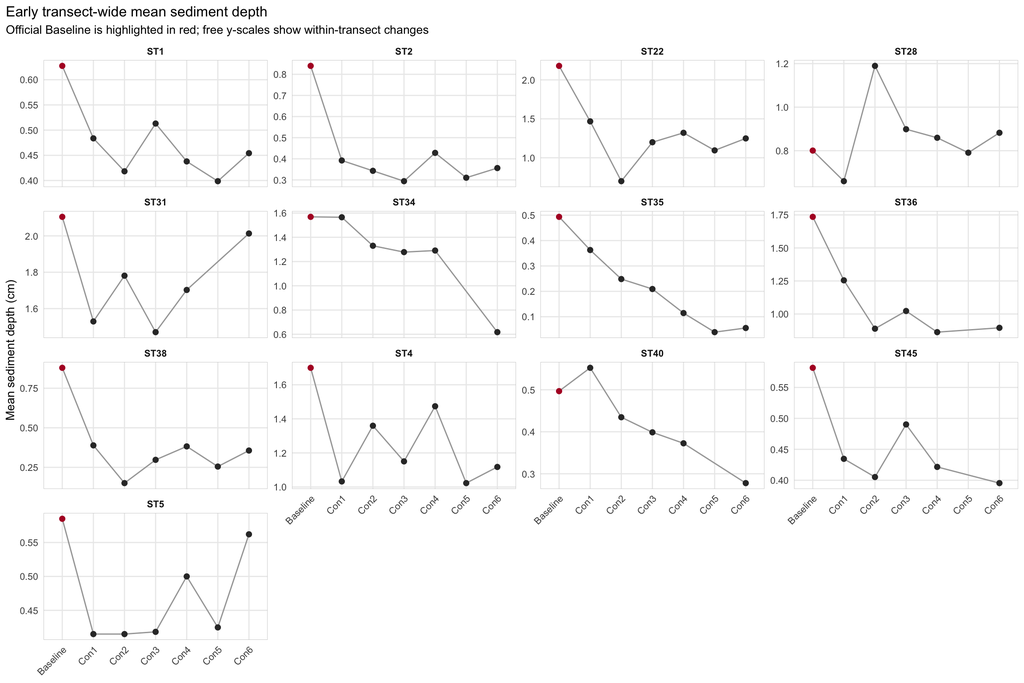

```r
transect_survey_means <- sediment_analysis %>%
  summarize(
    transect_mean_cm = mean(meter_mean_sediment_cm),
    transect_median_cm = median(meter_mean_sediment_cm),
    .by = c(transect, date, survey, survey_n)
  ) %>%
  arrange(transect, survey_n)

early_transect_means <- transect_survey_means %>%
  filter(survey_n <= 6) %>%
  mutate(
    survey_label = factor(
      survey,
      levels = c("Baseline", paste0("Con", 1:6))
    )
  )

ggplot(
  early_transect_means,
  aes(x = survey_label, y = transect_mean_cm, group = transect)
) +
  geom_line(color = "grey65", linewidth = 0.5) +
  geom_point(
    aes(color = survey_label == "Baseline"),
    size = 1.8
  ) +
  facet_wrap(~ transect, scales = "free_y", ncol = 4) +
  scale_color_manual(
    values = c(`TRUE` = "#b2182b", `FALSE` = "#333333"),
    guide = "none"
  ) +
  labs(
    title = "Early transect-wide mean sediment depth",
    subtitle = "Official Baseline is highlighted in red; free y-scales show within-transect changes",
    x = NULL,
    y = "Mean sediment depth (cm)"
  ) +
  theme(
    axis.text.x = element_text(angle = 45, hjust = 1),
    panel.border = element_rect(color = "grey80", fill = NA, linewidth = 0.3),
    strip.text = element_text(face = "bold")
  )
```

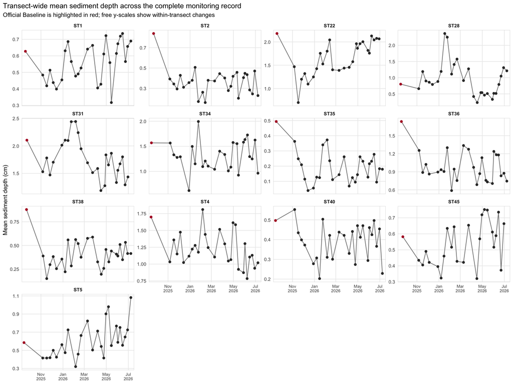

```r
ggplot(
  transect_survey_means,
  aes(x = date, y = transect_mean_cm, group = transect)
) +
  geom_line(color = "grey55", linewidth = 0.55) +
  geom_point(
    aes(color = survey == "Baseline"),
    size = 1.5
  ) +
  facet_wrap(~ transect, scales = "free_y", ncol = 4) +
  scale_color_manual(
    values = c(`TRUE` = "#b2182b", `FALSE` = "#333333"),
    guide = "none"
  ) +
  scale_x_date(
    date_breaks = "2 months",
    date_labels = "%b\n%Y",
    expand = expansion(mult = c(0.02, 0.03))
  ) +
  labs(
    title = "Transect-wide mean sediment depth across the complete monitoring record",
    subtitle = "Official Baseline is highlighted in red; free y-scales show within-transect changes",
    x = NULL,
    y = "Mean sediment depth (cm)"
  ) +
  theme(
    axis.text.x = element_text(size = 7),
    panel.border = element_rect(color = "grey80", fill = NA, linewidth = 0.3),
    strip.text = element_text(face = "bold")
  )
```

## 3.2 Meter-matched elevation above Con1 and Con2

Comparisons are paired by transect and meter. Positive differences mean that the official baseline depth was greater than the comparison survey at the same location.

```r
early_meter_wide <- sediment_analysis %>%
  filter(survey_n %in% 0:2) %>%
  select(transect, meter, survey_n, meter_mean_sediment_cm) %>%
  mutate(
    survey_key = recode(
      as.character(survey_n),
      `0` = "baseline_cm",
      `1` = "con1_cm",
      `2` = "con2_cm"
    )
  ) %>%
  select(-survey_n) %>%
  pivot_wider(names_from = survey_key, values_from = meter_mean_sediment_cm) %>%
  mutate(
    baseline_minus_con1_cm = baseline_cm - con1_cm,
    baseline_minus_con2_cm = baseline_cm - con2_cm,
    baseline_minus_early_mean_cm = baseline_cm - (con1_cm + con2_cm) / 2
  )

paired_long <- early_meter_wide %>%
  pivot_longer(
    c(baseline_minus_con1_cm, baseline_minus_con2_cm),
    names_to = "comparison",
    values_to = "baseline_excess_cm"
  ) %>%
  mutate(
    comparison = recode(
      comparison,
      baseline_minus_con1_cm = "Baseline - Con1",
      baseline_minus_con2_cm = "Baseline - Con2"
    )
  )

paired_summary <- paired_long %>%
  summarize(
    n_meter_positions = n(),
    mean_excess_cm = mean(baseline_excess_cm),
    median_excess_cm = median(baseline_excess_cm),
    pct_baseline_higher = mean(baseline_excess_cm > 0),
    .by = c(transect, comparison)
  )

paired_summary
```

```
## # A tibble: 26 × 6
##    transect comparison      n_meter_positions mean_excess_cm median_excess_cm
##    <chr>    <chr>                       <int>          <dbl>            <dbl>
##  1 ST34     Baseline - Con1                51        0.00327           -0.333
##  2 ST34     Baseline - Con2                51        0.239              0.333
##  3 ST28     Baseline - Con1                51        0.141              0
##  4 ST28     Baseline - Con2                51       -0.389             -0.5
##  5 ST35     Baseline - Con1                51        0.131              0
##  6 ST35     Baseline - Con2                51        0.245              0
##  7 ST4      Baseline - Con1                51        0.667              0.5
##  8 ST4      Baseline - Con2                51        0.340              0
##  9 ST5      Baseline - Con1                51        0.170              0.167
## 10 ST5      Baseline - Con2                51        0.170              0
## # ℹ 16 more rows
## # ℹ 1 more variable: pct_baseline_higher <dbl>
```

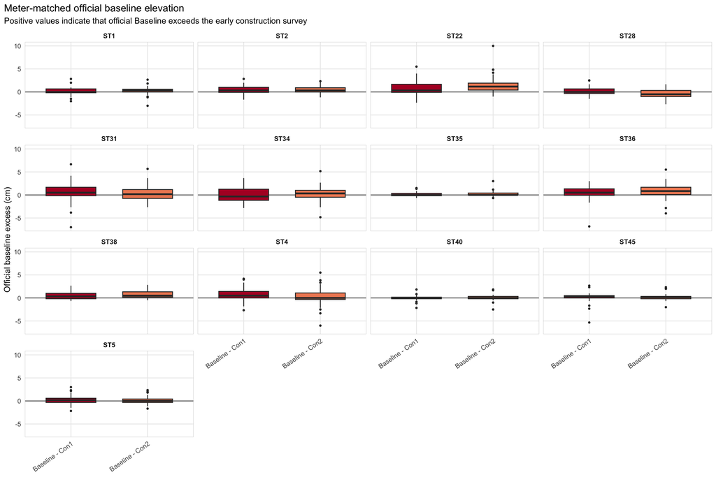

```r
ggplot(
  paired_long,
  aes(x = comparison, y = baseline_excess_cm, fill = comparison)
) +
  geom_hline(yintercept = 0, color = "grey30", linewidth = 0.4) +
  geom_boxplot(width = 0.65, outlier.size = 0.7) +
  facet_wrap(~ transect, ncol = 4) +
  scale_fill_manual(values = c(
    "Baseline - Con1" = "#b2182b",
    "Baseline - Con2" = "#ef8a62"
  )) +
  labs(
    title = "Meter-matched official baseline elevation",
    subtitle = "Positive values indicate that official Baseline exceeds the early construction survey",
    x = NULL,
    y = "Official baseline excess (cm)",
    fill = NULL
  ) +
  guides(fill = "none") +
  theme(
    axis.text.x = element_text(angle = 35, hjust = 1),
    panel.border = element_rect(color = "grey80", fill = NA, linewidth = 0.3),
    strip.text = element_text(face = "bold")
  )
```

## 3.3 Paired tests by transect

The Wilcoxon signed-rank test evaluates whether paired differences are centered at zero. The exact binomial sign test asks only whether positive differences outnumber negative differences, making it less sensitive to unusually large values. False-discovery-rate-adjusted p-values account for testing multiple transects.

```r
safe_wilcox_p <- function(x) {
  tryCatch(
    wilcox.test(x, mu = 0, exact = FALSE)$p.value,
    error = function(e) NA_real_
  )
}

safe_sign_p <- function(x) {
  x <- x[x != 0 & !is.na(x)]
  if (length(x) == 0) return(NA_real_)
  binom.test(sum(x > 0), length(x), p = 0.5)$p.value
}

paired_tests <- paired_long %>%
  summarize(
    n = n(),
    median_excess_cm = median(baseline_excess_cm),
    pct_baseline_higher = mean(baseline_excess_cm > 0),
    wilcoxon_p = safe_wilcox_p(baseline_excess_cm),
    sign_test_p = safe_sign_p(baseline_excess_cm),
    .by = c(transect, comparison)
  ) %>%
  mutate(
    wilcoxon_fdr = p.adjust(wilcoxon_p, method = "BH"),
    sign_test_fdr = p.adjust(sign_test_p, method = "BH"),
    .by = comparison
  ) %>%
  arrange(comparison, transect)

paired_tests
```

```
## # A tibble: 26 × 9
##    transect comparison         n median_excess_cm pct_baseline_higher wilcoxon_p
##    <chr>    <chr>          <int>            <dbl>               <dbl>      <dbl>
##  1 ST1      Baseline - Co…    51            0                   0.490   0.198
##  2 ST2      Baseline - Co…    51            0.333               0.588   0.000498
##  3 ST22     Baseline - Co…    51            0.333               0.667   0.000821
##  4 ST28     Baseline - Co…    51            0                   0.490   0.379
##  5 ST31     Baseline - Co…    51            0.5                 0.667   0.0171
##  6 ST34     Baseline - Co…    51           -0.333               0.412   0.892
##  7 ST35     Baseline - Co…    51            0                   0.412   0.0878
##  8 ST36     Baseline - Co…    51            0.5                 0.686   0.00152
##  9 ST38     Baseline - Co…    51            0.333               0.627   0.000178
## 10 ST4      Baseline - Co…    51            0.5                 0.667   0.00457
## # ℹ 16 more rows
## # ℹ 3 more variables: sign_test_p <dbl>, wilcoxon_fdr <dbl>,
## #   sign_test_fdr <dbl>
```

## 3.4 Transect-level robustness tests

Adjacent meter positions are not independent ecological replicates. The tests below therefore reduce each transect to its mean paired difference and treat the 13 transects as the independent analysis units. These are the primary tests for whether official-baseline elevation is consistent across the monitoring area; the meter-level tests above describe within-transect spatial consistency.

```r
transect_level_differences <- paired_long %>%
  summarize(
    mean_baseline_excess_cm = mean(baseline_excess_cm),
    median_baseline_excess_cm = median(baseline_excess_cm),
    .by = c(transect, comparison)
  )

transect_level_tests <- transect_level_differences %>%
  summarize(
    n_transects = n(),
    mean_of_transect_means_cm = mean(mean_baseline_excess_cm),
    median_of_transect_means_cm = median(mean_baseline_excess_cm),
    pct_transects_baseline_higher = mean(mean_baseline_excess_cm > 0),
    wilcoxon_p = safe_wilcox_p(mean_baseline_excess_cm),
    sign_test_p = safe_sign_p(mean_baseline_excess_cm),
    .by = comparison
  )

transect_level_tests
```

```
## # A tibble: 2 × 7
##   comparison      n_transects mean_of_transect_means_cm median_of_transect_mea…¹
##   <chr>                 <int>                     <dbl>                    <dbl>
## 1 Baseline - Con1          13                     0.312                    0.170
## 2 Baseline - Con2          13                     0.379                    0.245
## # ℹ abbreviated name: ¹median_of_transect_means_cm
## # ℹ 3 more variables: pct_transects_baseline_higher <dbl>, wilcoxon_p <dbl>,
## #   sign_test_p <dbl>
```

## 3.5 Is Baseline to Con1 an unusual transition?

This comparison uses transect-wide means so each transect contributes equally. The signed Baseline-to-Con1 shift is compared with each subsequent early shift through Con6. A strongly negative first shift that is larger than ordinary construction-to-construction changes supports the interpretation that Baseline captured an unusual state.

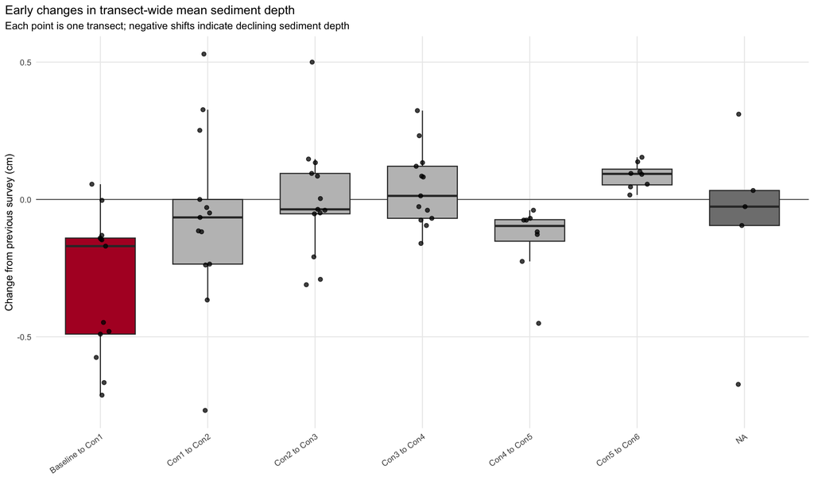

```r
early_transitions <- transect_survey_means %>%
  filter(survey_n <= 6) %>%
  arrange(transect, survey_n) %>%
  mutate(
    previous_survey_n = lag(survey_n),
    transition_delta_cm = transect_mean_cm - lag(transect_mean_cm),
    transition = case_when(
      survey_n == 1 ~ "Baseline to Con1",
      TRUE ~ paste0("Con", previous_survey_n, " to Con", survey_n)
    ),
    .by = transect
  ) %>%
  filter(!is.na(transition_delta_cm)) %>%
  mutate(
    transition = factor(
      transition,
      levels = c(
        "Baseline to Con1",
        "Con1 to Con2",
        "Con2 to Con3",
        "Con3 to Con4",
        "Con4 to Con5",
        "Con5 to Con6"
      )
    )
  )

transition_summary <- early_transitions %>%
  summarize(
    n_transects = n(),
    mean_shift_cm = mean(transition_delta_cm),
    median_shift_cm = median(transition_delta_cm),
    mean_absolute_shift_cm = mean(abs(transition_delta_cm)),
    .by = transition
  )

transition_by_transect <- early_transitions %>%
  summarize(
    baseline_to_con1_cm = first(
      transition_delta_cm[transition == "Baseline to Con1"]
    ),
    typical_later_shift_cm = median(
      transition_delta_cm[transition != "Baseline to Con1"]
    ),
    baseline_absolute_shift_cm = abs(baseline_to_con1_cm),
    typical_later_absolute_shift_cm = median(
      abs(transition_delta_cm[transition != "Baseline to Con1"])
    ),
    .by = transect
  )

transition_test <- transition_by_transect %>%
  summarize(
    paired_absolute_shift_p = wilcox.test(
      baseline_absolute_shift_cm,
      typical_later_absolute_shift_cm,
      alternative = "greater",
      paired = TRUE,
      exact = FALSE
    )$p.value,
    paired_signed_shift_p = wilcox.test(
      baseline_to_con1_cm,
      typical_later_shift_cm,
      alternative = "less",
      paired = TRUE,
      exact = FALSE
    )$p.value
  )

ggplot(
  early_transitions,
  aes(x = transition, y = transition_delta_cm)
) +
  geom_hline(yintercept = 0, color = "grey30", linewidth = 0.4) +
  geom_boxplot(
    aes(fill = transition == "Baseline to Con1"),
    width = 0.65,
    outlier.shape = NA
  ) +
  geom_jitter(width = 0.1, height = 0, size = 1.6, alpha = 0.75) +
  scale_fill_manual(
    values = c(`TRUE` = "#b2182b", `FALSE` = "grey75"),
    guide = "none"
  ) +
  labs(
    title = "Early changes in transect-wide mean sediment depth",
    subtitle = "Each point is one transect; negative shifts indicate declining sediment depth",
    x = NULL,
    y = "Change from previous survey (cm)"
  ) +
  theme(axis.text.x = element_text(angle = 35, hjust = 1))
```

```r
transition_summary
```

```
## # A tibble: 7 × 5
##   transition    n_transects mean_shift_cm median_shift_cm mean_absolute_shift_cm
##   <fct>               <int>         <dbl>           <dbl>                  <dbl>
## 1 Baseline to …          13      -0.312           -0.170                  0.320
## 2 Con1 to Con2           13      -0.0674          -0.0654                 0.238
## 3 Con2 to Con3           13      -0.00176         -0.0359                 0.150
## 4 Con3 to Con4           13       0.0405           0.0131                 0.112
## 5 Con4 to Con5            8      -0.147           -0.0964                 0.147
## 6 Con5 to Con6            8       0.0870           0.0931                 0.0870
## 7 <NA>                    5      -0.0902          -0.0261                 0.227
```

```r
transition_test
```

```
## # A tibble: 1 × 2
##   paired_absolute_shift_p paired_signed_shift_p
##                     <dbl>                 <dbl>
## 1                 0.00713               0.00713
```

# 4 When does a new sediment regime appear?

Later surveys may improve the estimate of ordinary background conditions, but only until the system begins to depart from that regime. A defensible expanded reference window therefore requires two findings: adding another survey should improve prediction of the next survey, and it should not coincide with a new, spatially selective or sustained shift that may reflect project-related flux.

## 4.1 Complete survey-to-survey transition scan

For every transect and meter, each observation is compared with the immediately preceding available survey. The transect mean is used as the independent unit for regional tests; meter-level summaries retain information about whether a shift is spatially widespread along a transect.

```r
meter_transitions <- sediment_analysis %>%
  arrange(transect, meter, survey_n) %>%
  mutate(
    previous_survey = lag(survey),
    previous_survey_n = lag(survey_n),
    previous_depth_cm = lag(meter_mean_sediment_cm),
    transition_delta_cm = meter_mean_sediment_cm - previous_depth_cm,
    .by = c(transect, meter)
  ) %>%
  filter(!is.na(previous_depth_cm)) %>%
  mutate(
    transition_label = paste0(previous_survey, " to ", survey)
  )

transect_transitions <- meter_transitions %>%
  summarize(
    mean_transition_cm = mean(transition_delta_cm),
    median_transition_cm = median(transition_delta_cm),
    mean_absolute_meter_change_cm = mean(abs(transition_delta_cm)),
    pct_meter_positions_increasing = mean(transition_delta_cm > 0),
    meter_wilcoxon_p = safe_wilcox_p(transition_delta_cm),
    .by = c(
      transect,
      predicted_impact_class,
      date,
      survey,
      survey_n,
      previous_survey,
      previous_survey_n,
      transition_label
    )
  ) %>%
  mutate(
    meter_wilcoxon_fdr = p.adjust(meter_wilcoxon_p, method = "BH"),
    .by = transect
  )

regional_transition_tests <- transect_transitions %>%
  summarize(
    n_transects = n(),
    regional_mean_shift_cm = mean(mean_transition_cm),
    regional_median_shift_cm = median(mean_transition_cm),
    pct_transects_increasing = mean(mean_transition_cm > 0),
    transect_wilcoxon_p = safe_wilcox_p(mean_transition_cm),
    transect_sign_p = safe_sign_p(mean_transition_cm),
    .by = c(date, survey, survey_n, previous_survey, transition_label)
  ) %>%
  arrange(survey_n) %>%
  mutate(
    transect_wilcoxon_fdr = p.adjust(transect_wilcoxon_p, method = "BH"),
    transect_sign_fdr = p.adjust(transect_sign_p, method = "BH")
  )

regional_transition_tests
```

```
## # A tibble: 40 × 13
##    date       survey survey_n previous_survey transition_label n_transects
##    <date>     <chr>     <int> <chr>           <chr>                  <int>
##  1 2025-11-06 Con1          1 Baseline        Baseline to Con1           8
##  2 2025-11-07 Con1          1 Baseline        Baseline to Con1           5
##  3 2025-11-17 Con2          2 Con1            Con1 to Con2              13
##  4 2025-11-26 Con3          3 Con2            Con2 to Con3              13
##  5 2025-12-05 Con4          4 Con3            Con3 to Con4              13
##  6 2025-12-14 Con5          5 Con4            Con4 to Con5               8
##  7 2025-12-29 Con6          6 Con5            Con5 to Con6               8
##  8 2025-12-29 Con6          6 Con4            Con4 to Con6               5
##  9 2026-01-07 Con7          7 Con6            Con6 to Con7              13
## 10 2026-01-15 Con8          8 Con7            Con7 to Con8              11
## # ℹ 30 more rows
## # ℹ 7 more variables: regional_mean_shift_cm <dbl>,
## #   regional_median_shift_cm <dbl>, pct_transects_increasing <dbl>,
## #   transect_wilcoxon_p <dbl>, transect_sign_p <dbl>,
## #   transect_wilcoxon_fdr <dbl>, transect_sign_fdr <dbl>
```

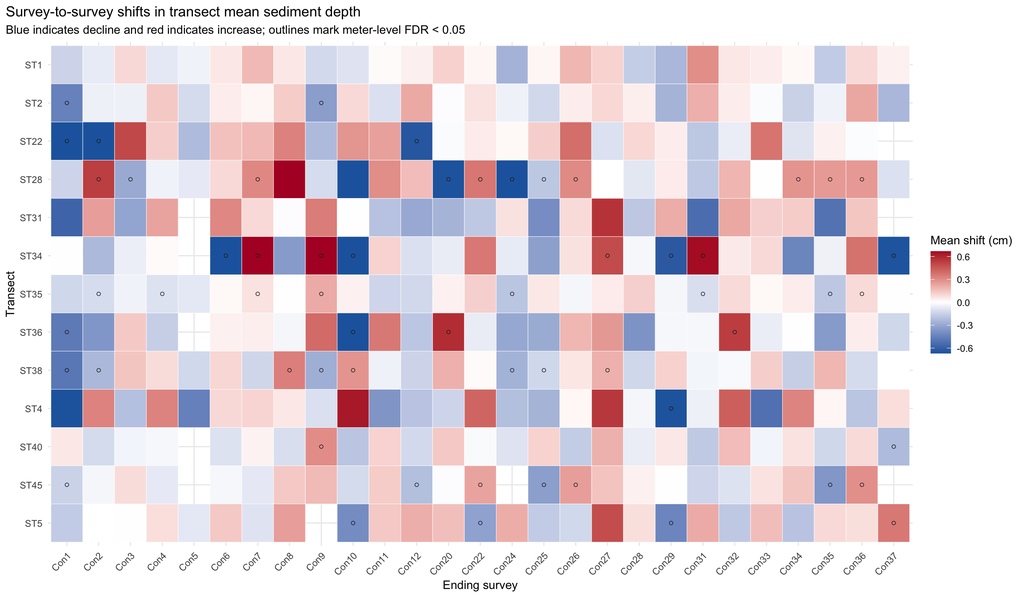

```r
transition_color_limit <- max(abs(quantile(
  transect_transitions$mean_transition_cm,
  probs = c(0.02, 0.98),
  na.rm = TRUE
)))

ggplot(
  transect_transitions,
  aes(
    x = fct_reorder(survey, survey_n),
    y = fct_rev(factor(transect)),
    fill = mean_transition_cm
  )
) +
  geom_tile(color = "white", linewidth = 0.15) +
  geom_point(
    data = transect_transitions %>%
      filter(meter_wilcoxon_fdr < 0.05),
    shape = 21,
    fill = NA,
    color = "grey15",
    size = 1.2,
    stroke = 0.35
  ) +
  scale_fill_gradient2(
    low = "#2166ac",
    mid = "white",
    high = "#b2182b",
    midpoint = 0,
    limits = c(-transition_color_limit, transition_color_limit),
    oob = scales::squish
  ) +
  labs(
    title = "Survey-to-survey shifts in transect mean sediment depth",
    subtitle = "Blue indicates decline and red indicates increase; outlines mark meter-level FDR < 0.05",
    x = "Ending survey",
    y = "Transect",
    fill = "Mean shift (cm)"
  ) +
  theme(axis.text.x = element_text(angle = 45, hjust = 1))
```

## 4.2 Deviations from the robust three-survey early state

The meter-specific Baseline-Con1-Con2 median is used here only as a diagnostic anchor. A project-related pattern would be more plausible if positive deviations emerge preferentially or earlier in transects with modeled exposure, rather than appearing synchronously across all transects.

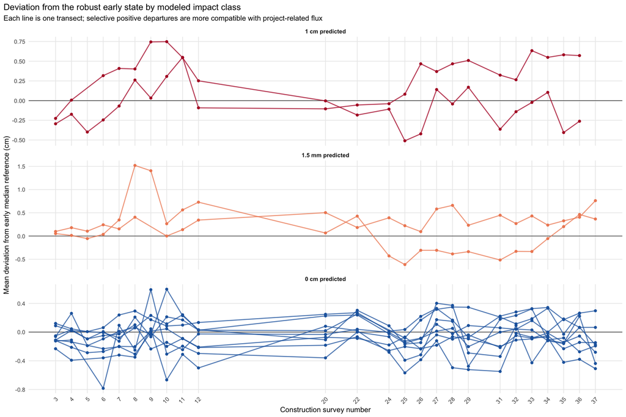

```r
robust_early_reference <- sediment_analysis %>%
  filter(survey_n %in% 0:2) %>%
  summarize(
    robust_early_reference_cm = median(meter_mean_sediment_cm),
    .by = c(transect, meter)
  )

survey_deviations <- sediment_analysis %>%
  filter(survey_n >= 3) %>%
  left_join(robust_early_reference, by = c("transect", "meter")) %>%
  mutate(
    deviation_cm = meter_mean_sediment_cm - robust_early_reference_cm
  ) %>%
  summarize(
    mean_deviation_cm = mean(deviation_cm),
    median_deviation_cm = median(deviation_cm),
    pct_meter_positions_increasing = mean(deviation_cm > 0),
    .by = c(
      transect,
      predicted_impact_class,
      date,
      survey,
      survey_n
    )
  )

ggplot(
  survey_deviations,
  aes(
    x = survey_n,
    y = mean_deviation_cm,
    color = predicted_impact_class,
    group = transect
  )
) +
  geom_hline(yintercept = 0, color = "grey30", linewidth = 0.4) +
  geom_line(linewidth = 0.65, alpha = 0.75) +
  geom_point(size = 1.3) +
  facet_wrap(~ predicted_impact_class, ncol = 1, scales = "free_y") +
  scale_color_manual(values = c(
    "1 cm predicted" = "#b2182b",
    "1.5 mm predicted" = "#ef8a62",
    "0 cm predicted" = "#2166ac"
  )) +
  scale_x_continuous(breaks = sort(unique(survey_deviations$survey_n))) +
  labs(
    title = "Deviation from the robust early state by modeled impact class",
    subtitle = "Each line is one transect; selective positive departures are more compatible with project-related flux",
    x = "Construction survey number",
    y = "Mean deviation from early median reference (cm)",
    color = "Modeled sedimentation"
  ) +
  guides(color = "none") +
  theme(
    axis.text.x = element_text(angle = 45, hjust = 1),
    strip.text = element_text(face = "bold")
  )
```

## 4.3 Sequential reference-window evaluation

Candidate windows are extended one survey at a time from Con1 through Con6. For each endpoint, both a mean and a median meter-specific reference are used to predict the next survey. A useful additional survey should reduce absolute next-survey error without causing a large systematic drift in the reference.

```r
reference_window_ends <- 1:6

sequential_references <- crossing(
  sediment_analysis %>% distinct(transect, meter),
  window_end = reference_window_ends,
  estimator = c("Mean", "Median")
) %>%
  left_join(
    sediment_analysis %>%
      select(transect, meter, survey_n, meter_mean_sediment_cm),
    by = c("transect", "meter"),
    relationship = "many-to-many"
  ) %>%
  filter(survey_n <= window_end) %>%
  summarize(
    reference_cm = if_else(
      first(estimator) == "Mean",
      mean(meter_mean_sediment_cm),
      median(meter_mean_sediment_cm)
    ),
    n_reference_surveys = n(),
    .by = c(transect, meter, window_end, estimator)
  )

sequential_evaluation <- sequential_references %>%
  left_join(
    sediment_analysis %>%
      select(
        transect,
        meter,
        next_survey_n = survey_n,
        next_depth_cm = meter_mean_sediment_cm
      ),
    by = c("transect", "meter"),
    relationship = "many-to-many"
  ) %>%
  filter(next_survey_n == window_end + 1) %>%
  mutate(next_delta_cm = next_depth_cm - reference_cm) %>%
  summarize(
    transect_next_bias_cm = mean(next_delta_cm),
    transect_next_mae_cm = mean(abs(next_delta_cm)),
    .by = c(transect, window_end, estimator)
  )

sequential_reference_drift <- sequential_references %>%
  arrange(transect, meter, estimator, window_end) %>%
  mutate(
    reference_drift_cm = reference_cm - lag(reference_cm),
    .by = c(transect, meter, estimator)
  ) %>%
  filter(!is.na(reference_drift_cm)) %>%
  summarize(
    transect_mean_reference_drift_cm = mean(reference_drift_cm),
    transect_absolute_reference_drift_cm = mean(abs(reference_drift_cm)),
    .by = c(transect, window_end, estimator)
  )

sequential_summary <- sequential_evaluation %>%
  summarize(
    median_next_bias_cm = median(transect_next_bias_cm),
    mean_absolute_transect_bias_cm = mean(abs(transect_next_bias_cm)),
    median_next_mae_cm = median(transect_next_mae_cm),
    .by = c(window_end, estimator)
  ) %>%
  left_join(
    sequential_reference_drift %>%
      summarize(
        median_absolute_reference_drift_cm = median(
          transect_absolute_reference_drift_cm
        ),
        .by = c(window_end, estimator)
      ),
    by = c("window_end", "estimator")
  )

sequential_summary
```

```
## # A tibble: 12 × 6
##    window_end estimator median_next_bias_cm mean_absolute_transect_bias_cm
##         <int> <chr>                   <dbl>                          <dbl>
##  1          1 Mean                  -0.137                          0.294
##  2          1 Median                -0.137                          0.294
##  3          2 Mean                  -0.175                          0.156
##  4          2 Median                -0.111                          0.130
##  5          3 Mean                  -0.0564                         0.104
##  6          3 Median                 0.0294                         0.0988
##  7          4 Mean                  -0.157                          0.174
##  8          4 Median                -0.0441                         0.0895
##  9          5 Mean                  -0.0784                         0.176
## 10          5 Median                 0.0343                         0.156
## 11          6 Mean                  -0.0430                         0.147
## 12          6 Median                 0.121                          0.178
## # ℹ 2 more variables: median_next_mae_cm <dbl>,
## #   median_absolute_reference_drift_cm <dbl>
```

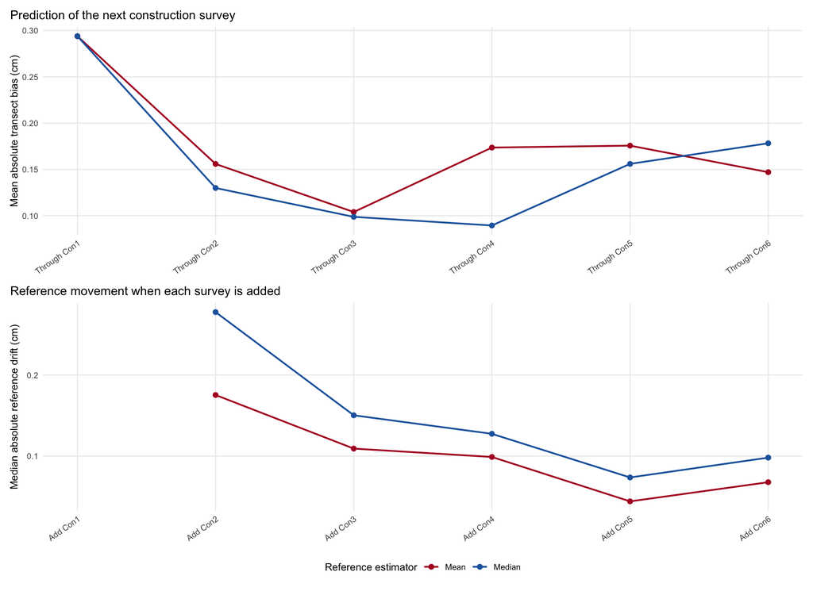

```r
window_bias_plot <- ggplot(
  sequential_summary,
  aes(
    x = window_end,
    y = mean_absolute_transect_bias_cm,
    color = estimator
  )
) +
  geom_line(linewidth = 0.8) +
  geom_point(size = 2) +
  scale_x_continuous(
    breaks = reference_window_ends,
    labels = paste0("Through Con", reference_window_ends)
  ) +
  scale_color_manual(values = c("Mean" = "#b2182b", "Median" = "#2166ac")) +
  labs(
    title = "Prediction of the next construction survey",
    x = NULL,
    y = "Mean absolute transect bias (cm)",
    color = "Reference estimator"
  ) +
  theme(axis.text.x = element_text(angle = 35, hjust = 1))

window_drift_plot <- ggplot(
  sequential_summary,
  aes(
    x = window_end,
    y = median_absolute_reference_drift_cm,
    color = estimator
  )
) +
  geom_line(linewidth = 0.8) +
  geom_point(size = 2) +
  scale_x_continuous(
    breaks = reference_window_ends,
    labels = paste0("Add Con", reference_window_ends)
  ) +
  scale_color_manual(values = c("Mean" = "#b2182b", "Median" = "#2166ac")) +
  labs(
    title = "Reference movement when each survey is added",
    x = NULL,
    y = "Median absolute reference drift (cm)",
    color = "Reference estimator"
  ) +
  theme(axis.text.x = element_text(angle = 35, hjust = 1))

window_bias_plot / window_drift_plot +
  plot_layout(guides = "collect") &
  theme(legend.position = "bottom")
```

The sequential analysis is intended to identify plausible reference windows, not mechanically choose the window with the smallest prediction error. The preferred endpoint should precede any sustained or impact-class-specific departure in the transition and deviation plots. Surveys after that point are outcomes to be detected, not observations to be absorbed into the reference.

# 5 Candidate alternative references

Four references are evaluated at each transect and meter:

1. **Official Baseline**: the regulatory pre-construction observation.
2. **Baseline-Con1-Con2 mean**: the current localized-analysis sensitivity reference; uses all three surveys but is sensitive to one high value.
3. **Baseline-Con1-Con2 median**: robust to one unusually high or low survey. If Baseline is the highest of the three, this selects the higher of Con1 and Con2 and is therefore conservative relative to their mean.
4. **Con1-Con2 mean**: excludes the official baseline and provides the clearest estimate of the early construction state, but has the greatest risk of absorbing genuine early project-related deposition.

```r
candidate_references <- early_meter_wide %>%
  transmute(
    transect,
    meter,
    `Official Baseline` = baseline_cm,
    `Baseline-Con1-Con2 mean` = (baseline_cm + con1_cm + con2_cm) / 3,
    `Baseline-Con1-Con2 median` = pmap_dbl(
      list(baseline_cm, con1_cm, con2_cm),
      ~ median(c(...))
    ),
    `Con1-Con2 mean` = (con1_cm + con2_cm) / 2
  ) %>%
  pivot_longer(
    -c(transect, meter),
    names_to = "reference_method",
    values_to = "reference_cm"
  ) %>%
  mutate(
    reference_method = factor(
      reference_method,
      levels = c(
        "Official Baseline",
        "Baseline-Con1-Con2 mean",
        "Baseline-Con1-Con2 median",
        "Con1-Con2 mean"
      )
    )
  )

candidate_contrasts <- candidate_references %>%
  select(transect, meter, reference_method, reference_cm) %>%
  pivot_wider(names_from = reference_method, values_from = reference_cm) %>%
  mutate(
    mean3_reduction_cm =
      `Official Baseline` - `Baseline-Con1-Con2 mean`,
    median3_reduction_cm =
      `Official Baseline` - `Baseline-Con1-Con2 median`,
    early2_reduction_cm =
      `Official Baseline` - `Con1-Con2 mean`
  )

candidate_contrast_summary <- candidate_contrasts %>%
  summarize(
    mean3_reduction_cm = mean(mean3_reduction_cm),
    median3_reduction_cm = mean(median3_reduction_cm),
    early2_reduction_cm = mean(early2_reduction_cm),
    pct_median3_below_official = mean(median3_reduction_cm > 0),
    .by = transect
  )

candidate_contrast_summary
```

```
## # A tibble: 13 × 5
##    transect mean3_reduction_cm median3_reduction_cm early2_reduction_cm
##    <chr>                 <dbl>                <dbl>               <dbl>
##  1 ST34                0.0806                0.167              0.121
##  2 ST28               -0.0828               -0.0458            -0.124
##  3 ST35                0.125                 0.167              0.188
##  4 ST4                 0.336                 0.487              0.503
##  5 ST5                 0.113                 0.265              0.170
##  6 ST40                0.00218              -0.0131             0.00327
##  7 ST1                 0.118                 0.235              0.176
##  8 ST36                0.442                 0.480              0.663
##  9 ST22                0.731                 0.686              1.10
## 10 ST2                 0.315                 0.435              0.472
## 11 ST38                0.406                 0.529              0.609
## 12 ST31                0.300                 0.408              0.449
## 13 ST45                0.108                 0.180              0.162
## # ℹ 1 more variable: pct_median3_below_official <dbl>
```

## 5.1 How often is each early survey selected by the median?

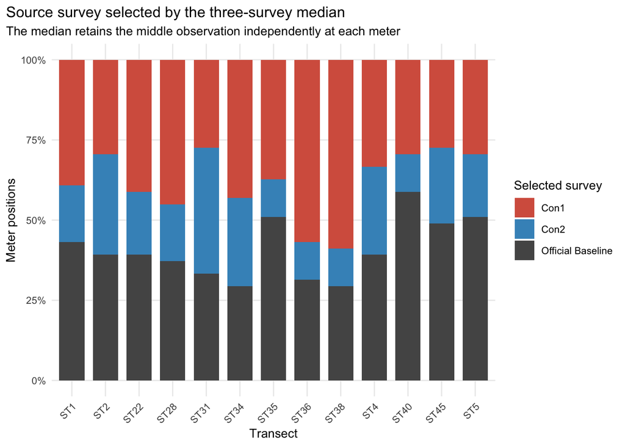

```r
median_source <- early_meter_wide %>%
  mutate(
    median_reference_cm = pmap_dbl(
      list(baseline_cm, con1_cm, con2_cm),
      ~ median(c(...))
    ),
    median_source = case_when(
      near(median_reference_cm, baseline_cm) ~ "Official Baseline",
      near(median_reference_cm, con1_cm) ~ "Con1",
      near(median_reference_cm, con2_cm) ~ "Con2",
      TRUE ~ "Tie"
    )
  ) %>%
  count(transect, median_source) %>%
  group_by(transect) %>%
  mutate(fraction = n / sum(n)) %>%
  ungroup()

ggplot(
  median_source,
  aes(x = transect, y = fraction, fill = median_source)
) +
  geom_col(width = 0.75) +
  scale_y_continuous(labels = scales::label_percent(accuracy = 1)) +
  scale_fill_manual(values = c(
    "Official Baseline" = "#555555",
    "Con1" = "#d6604d",
    "Con2" = "#4393c3",
    "Tie" = "#cccccc"
  )) +
  labs(
    title = "Source survey selected by the three-survey median",
    subtitle = "The median retains the middle observation independently at each meter",
    x = "Transect",
    y = "Meter positions",
    fill = "Selected survey"
  ) +
  theme(axis.text.x = element_text(angle = 45, hjust = 1))
```

# 6 Holdout evaluation using Con3-Con6

Con3-Con6 are not used to construct any candidate. Their deltas provide a common early holdout period for evaluating how strongly each reference systematically centers later observations above or below zero. This is a stability diagnostic, not proof that the holdout surveys are impact-free.

```r
holdout_deltas <- sediment_analysis %>%
  filter(survey_n %in% 3:6) %>%
  select(transect, meter, date, survey, survey_n, meter_mean_sediment_cm) %>%
  left_join(
    candidate_references,
    by = c("transect", "meter"),
    relationship = "many-to-many"
  ) %>%
  mutate(delta_cm = meter_mean_sediment_cm - reference_cm)

holdout_by_transect <- holdout_deltas %>%
  summarize(
    mean_bias_cm = mean(delta_cm),
    median_bias_cm = median(delta_cm),
    mean_absolute_delta_cm = mean(abs(delta_cm)),
    pct_below_reference = mean(delta_cm < 0),
    .by = c(transect, reference_method)
  )

holdout_overall <- holdout_by_transect %>%
  summarize(
    median_transect_bias_cm = median(mean_bias_cm),
    mean_absolute_transect_bias_cm = mean(abs(mean_bias_cm)),
    median_meter_absolute_delta_cm = median(mean_absolute_delta_cm),
    median_pct_below_reference = median(pct_below_reference),
    .by = reference_method
  ) %>%
  arrange(mean_absolute_transect_bias_cm)

holdout_overall
```

```
## # A tibble: 4 × 5
##   reference_method          median_transect_bias_cm mean_absolute_transect_bia…¹
##   <fct>                                       <dbl>                        <dbl>
## 1 Con1-Con2 mean                           -0.00490                        0.100
## 2 Baseline-Con1-Con2 median                -0.0270                         0.133
## 3 Baseline-Con1-Con2 mean                  -0.150                          0.164
## 4 Official Baseline                        -0.389                          0.403
## # ℹ abbreviated name: ¹mean_absolute_transect_bias_cm
## # ℹ 2 more variables: median_meter_absolute_delta_cm <dbl>,
## #   median_pct_below_reference <dbl>
```

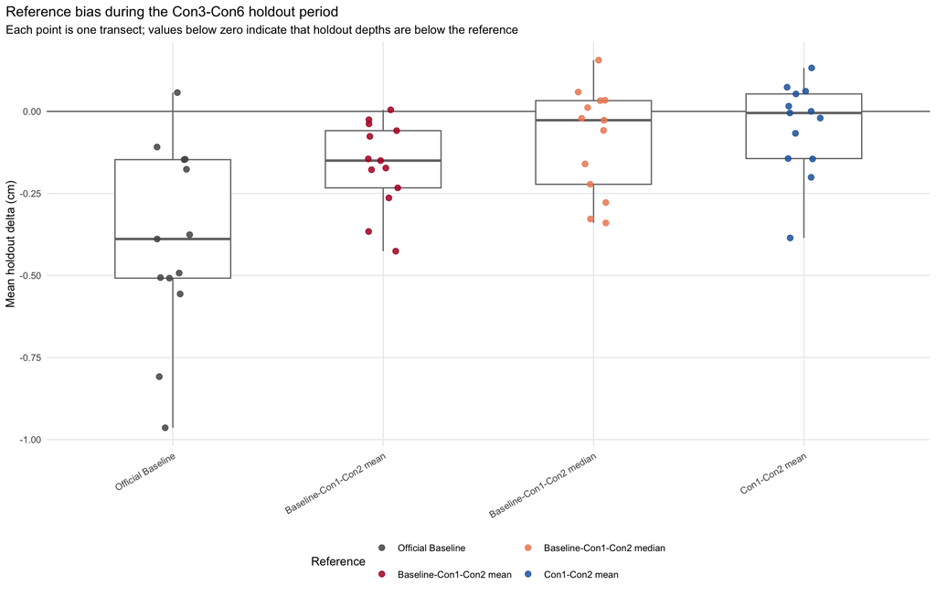

```r
ggplot(
  holdout_by_transect,
  aes(x = reference_method, y = mean_bias_cm, color = reference_method)
) +
  geom_hline(yintercept = 0, color = "grey30", linewidth = 0.4) +
  geom_boxplot(width = 0.55, outlier.shape = NA, color = "grey45") +
  geom_point(
    aes(group = transect),
    position = position_jitter(width = 0.08, height = 0),
    size = 2,
    alpha = 0.85
  ) +
  scale_color_manual(values = c(
    "Official Baseline" = "#555555",
    "Baseline-Con1-Con2 mean" = "#b2182b",
    "Baseline-Con1-Con2 median" = "#ef8a62",
    "Con1-Con2 mean" = "#2166ac"
  )) +
  labs(
    title = "Reference bias during the Con3-Con6 holdout period",
    subtitle = "Each point is one transect; values below zero indicate that holdout depths are below the reference",
    x = NULL,
    y = "Mean holdout delta (cm)",
    color = "Reference"
  ) +
  guides(color = guide_legend(nrow = 2)) +
  theme(
    axis.text.x = element_text(angle = 30, hjust = 1),
    legend.position = "bottom"
  )
```

# 7 Bootstrap uncertainty for reference differences

Meters are resampled within each transect. The intervals quantify uncertainty in the average difference between the official baseline and each alternative; they do not account for temporal autocorrelation or prove that one reference is causally correct.

```r
set.seed(240917)

bootstrap_mean_ci <- function(x, n_boot = 4000) {
  boot_means <- replicate(
    n_boot,
    mean(sample(x, size = length(x), replace = TRUE))
  )
  tibble(
    estimate = mean(x),
    lower_95 = quantile(boot_means, 0.025),
    upper_95 = quantile(boot_means, 0.975)
  )
}

bootstrap_differences <- candidate_contrasts %>%
  select(
    transect,
    `Baseline-Con1-Con2 mean` = mean3_reduction_cm,
    `Baseline-Con1-Con2 median` = median3_reduction_cm,
    `Con1-Con2 mean` = early2_reduction_cm
  ) %>%
  pivot_longer(
    -transect,
    names_to = "alternative_reference",
    values_to = "official_minus_alternative_cm"
  ) %>%
  nest(.by = c(transect, alternative_reference)) %>%
  mutate(
    ci = map(
      data,
      ~ bootstrap_mean_ci(.x$official_minus_alternative_cm)
    )
  ) %>%
  select(-data) %>%
  unnest(ci)

bootstrap_differences
```

```
## # A tibble: 39 × 5
##    transect alternative_reference     estimate lower_95 upper_95
##    <chr>    <chr>                        <dbl>    <dbl>    <dbl>
##  1 ST34     Baseline-Con1-Con2 mean     0.0806  -0.173    0.341
##  2 ST34     Baseline-Con1-Con2 median   0.167   -0.101    0.428
##  3 ST34     Con1-Con2 mean              0.121   -0.258    0.505
##  4 ST28     Baseline-Con1-Con2 mean    -0.0828  -0.225    0.0643
##  5 ST28     Baseline-Con1-Con2 median  -0.0458  -0.186    0.0980
##  6 ST28     Con1-Con2 mean             -0.124   -0.335    0.0948
##  7 ST35     Baseline-Con1-Con2 mean     0.125    0.0425   0.218
##  8 ST35     Baseline-Con1-Con2 median   0.167    0.0752   0.265
##  9 ST35     Con1-Con2 mean              0.188    0.0637   0.327
## 10 ST4      Baseline-Con1-Con2 mean     0.336    0.0763   0.600
## # ℹ 29 more rows
```

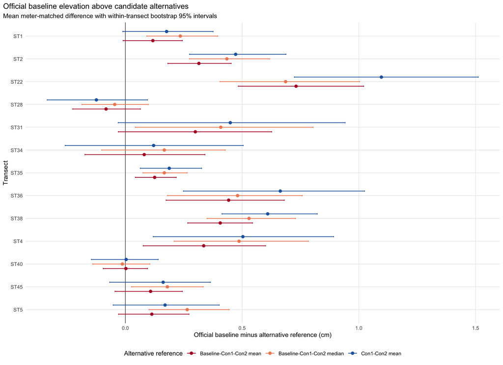

```r
ggplot(
  bootstrap_differences,
  aes(
    x = estimate,
    y = fct_rev(factor(transect)),
    xmin = lower_95,
    xmax = upper_95,
    color = alternative_reference
  )
) +
  geom_vline(xintercept = 0, color = "grey30", linewidth = 0.4) +
  geom_errorbarh(
    position = position_dodge(width = 0.6),
    height = 0.15,
    linewidth = 0.5
  ) +
  geom_point(position = position_dodge(width = 0.6), size = 1.8) +
  scale_color_manual(values = c(
    "Baseline-Con1-Con2 mean" = "#b2182b",
    "Baseline-Con1-Con2 median" = "#ef8a62",
    "Con1-Con2 mean" = "#2166ac"
  )) +
  labs(
    title = "Official baseline elevation above candidate alternatives",
    subtitle = "Mean meter-matched difference with within-transect bootstrap 95% intervals",
    x = "Official baseline minus alternative reference (cm)",
    y = "Transect",
    color = "Alternative reference"
  ) +
  theme(legend.position = "bottom")
```

# 8 Regulatory-threshold sensitivity

The practical consequence of reference choice is evaluated using cumulative net exceedance at 1.5 mm, 5 mm, and 1 cm. Positive values mean that accumulation prevalence exceeds equivalent-loss prevalence.

```r
regulatory_thresholds <- tibble(
  threshold_cm = c(0.15, 0.5, 1),
  threshold_label = factor(
    c("1.5 mm", "5 mm", "1 cm"),
    levels = c("1.5 mm", "5 mm", "1 cm")
  )
)

candidate_all_deltas <- sediment_analysis %>%
  filter(survey_n >= 3) %>%
  select(transect, meter, date, survey, survey_n, meter_mean_sediment_cm) %>%
  left_join(
    candidate_references,
    by = c("transect", "meter"),
    relationship = "many-to-many"
  ) %>%
  mutate(delta_cm = meter_mean_sediment_cm - reference_cm)

threshold_sensitivity <- crossing(
  candidate_all_deltas,
  regulatory_thresholds
) %>%
  summarize(
    accumulation_fraction = mean(delta_cm >= threshold_cm),
    loss_fraction = mean(delta_cm <= -threshold_cm),
    net_exceedance = accumulation_fraction - loss_fraction,
    .by = c(
      transect,
      date,
      survey,
      survey_n,
      reference_method,
      threshold_cm,
      threshold_label
    )
  )

threshold_sensitivity_summary <- threshold_sensitivity %>%
  summarize(
    median_net_exceedance = median(net_exceedance),
    maximum_net_exceedance = max(net_exceedance),
    pct_surveys_positive = mean(net_exceedance > 0),
    .by = c(reference_method, threshold_label)
  )

threshold_sensitivity_summary
```

```
## # A tibble: 12 × 5
##    reference_method threshold_label median_net_exceedance maximum_net_exceedance
##    <fct>            <fct>                           <dbl>                  <dbl>
##  1 Official Baseli… 1.5 mm                        -0.216                   0.608
##  2 Official Baseli… 5 mm                          -0.157                   0.471
##  3 Official Baseli… 1 cm                          -0.118                   0.294
##  4 Baseline-Con1-C… 1.5 mm                        -0.137                   0.667
##  5 Baseline-Con1-C… 5 mm                          -0.0784                  0.549
##  6 Baseline-Con1-C… 1 cm                          -0.0196                  0.314
##  7 Baseline-Con1-C… 1.5 mm                        -0.0588                  0.804
##  8 Baseline-Con1-C… 5 mm                          -0.0196                  0.667
##  9 Baseline-Con1-C… 1 cm                           0                       0.373
## 10 Con1-Con2 mean   1.5 mm                         0                       0.745
## 11 Con1-Con2 mean   5 mm                           0.0196                  0.608
## 12 Con1-Con2 mean   1 cm                           0.0196                  0.431
## # ℹ 1 more variable: pct_surveys_positive <dbl>
```

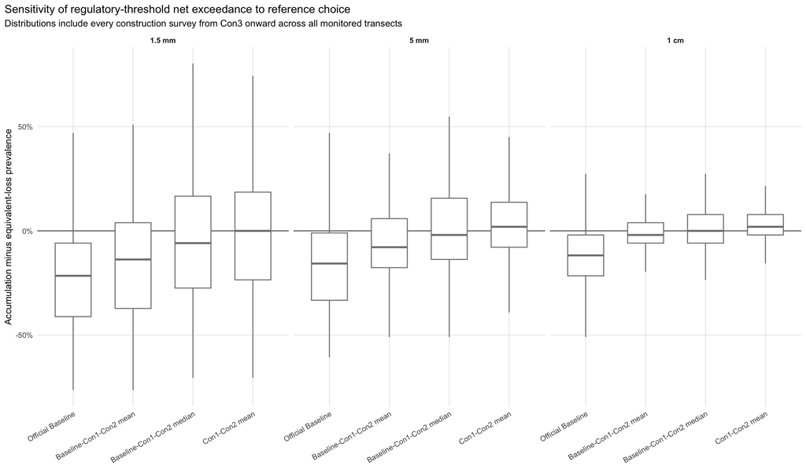

```r
ggplot(
  threshold_sensitivity,
  aes(x = reference_method, y = net_exceedance, color = reference_method)
) +
  geom_hline(yintercept = 0, color = "grey30", linewidth = 0.4) +
  geom_boxplot(outlier.shape = NA, width = 0.6, color = "grey50") +
  facet_wrap(~ threshold_label, nrow = 1) +
  scale_y_continuous(labels = scales::label_percent(accuracy = 1)) +
  scale_color_manual(values = c(
    "Official Baseline" = "#555555",
    "Baseline-Con1-Con2 mean" = "#b2182b",
    "Baseline-Con1-Con2 median" = "#ef8a62",
    "Con1-Con2 mean" = "#2166ac"
  )) +
  labs(
    title = "Sensitivity of regulatory-threshold net exceedance to reference choice",
    subtitle = "Distributions include every construction survey from Con3 onward across all monitored transects",
    x = NULL,
    y = "Accumulation minus equivalent-loss prevalence",
    color = "Reference"
  ) +
  guides(color = guide_legend(nrow = 2)) +
  theme(
    axis.text.x = element_text(angle = 30, hjust = 1),
    legend.position = "bottom",
    strip.text = element_text(face = "bold")
  )
```

# 9 Decision matrix

```r
decision_matrix <- tribble(
  ~reference_method, ~official_status, ~outlier_resistance, ~early_deposition_risk, ~interpretive_note,
  "Official Baseline", "Regulatory baseline", "None", "None", "Direct BMP comparison, but may represent a transient high state",
  "Baseline-Con1-Con2 mean", "Sensitivity reference", "Low", "Moderate", "Uses all three surveys but a high baseline still pulls the reference upward",
  "Baseline-Con1-Con2 median", "Sensitivity reference", "High for one anomalous survey", "Moderate", "Retains official data and selects the middle early observation at each meter",
  "Con1-Con2 mean", "Sensitivity reference", "Not affected by official baseline", "Highest", "Best description of the early construction state, but most vulnerable to absorbing early effects"
)

decision_matrix
```

```
## # A tibble: 4 × 5
##   reference_method      official_status outlier_resistance early_deposition_risk
##   <chr>                 <chr>           <chr>              <chr>
## 1 Official Baseline     Regulatory bas… None               None
## 2 Baseline-Con1-Con2 m… Sensitivity re… Low                Moderate
## 3 Baseline-Con1-Con2 m… Sensitivity re… High for one anom… Moderate
## 4 Con1-Con2 mean        Sensitivity re… Not affected by o… Highest
## # ℹ 1 more variable: interpretive_note <chr>
```

# 10 Provisional interpretation

Across the 13 monitored transects, the official baseline is significantly higher than Con1 at 7 transects and significantly higher than Con2 at 6 transects after false-discovery rate adjustment. Averaged across all paired meter positions, the official baseline exceeds the Con1-Con2 mean by 0.35 cm. At the transect level, the Baseline-to-Con1 shift is larger than each transect’s typical early absolute shift (paired p = 0.0071).

The candidate with the smallest mean absolute transect-level bias during the Con3-Con6 holdout is **Con1-Con2 mean**. That result should be weighed against regulatory continuity and the possibility that early construction surveys already include project effects.

For a single robust sensitivity reference applied consistently across transects, the **meter-specific Baseline-Con1-Con2 median** is a strong default candidate because it:

- uses the official baseline rather than discarding it;
- resists one unusually high or low early survey;
- remains meter-matched and therefore preserves localized spatial structure;
- is conservative relative to the Con1-Con2 mean whenever Baseline is the highest of the three observations.

The official baseline should still be retained in regulatory reporting, with the robust alternative presented as a clearly labeled sensitivity analysis. Before changing the localized-analysis workflow, the statistical evidence in this report should be considered alongside field notes, sampling conditions, seasonality, construction timing, and any documented method changes.